# California Groundwater Mass Balance Projections

Lauren Harris

11/18/2021

### Overview

This document analyzes the future of California’s groundwater supply. Analyses are made under business as usual conditions, meaning we assume that little about water use will change over time (assumptions listed in next section). First, the change in California groundwater from 2000 to 2050 is predicted. Second, the change in the total amount of groundwater is estimated under three scenarios with different levels of initial stored groundwater. Groundwater storage estimates are difficult to know without error because the only thing that can be measured is inputs and outputs. Inputs refer to groundwater recharge, an event which occurs when water is added to groundwater via infiltration from rain. Outputs are mainly anthropogenic, and refer to groundwater discharge, where water exits the reservoir. Examples of this include pumping water for agriculture. Based on the results in this analysis, California should expect decreasing groundwater supplies. Net groundwater change is negative, so groundwater is being reduced at a rate faster than it is being replenished. Considering a business as usual situation, California should run out of groundwater sometime between 2023 and 2050, with a mean expected year of 2037.

### Source of Data

Data comes from “Visualising a Stochastic Model of Californian Water Resources Using Sankey Diagrams” by Curmi et al. (2013) as published in the journal Water Resources Management. The paper analyzes two models. The first model is a business as usual scenario in which there are no major changes made to water use. The second model anticipates a 20% reduction in average irrigated water use introduced in 2020 and a water use limit of 31.6×10$^9$ m$^3$ for agriculture.

Assumptions (both models):

- The population is estimated to increase from 33 million in 2000 to 55 million
- Food demand from higher population is met by imports
- A policy is introduced to reduce urban per-capita water use by 2020
- Average groundwater will still meet about 30% of California’s urban and agricultural water demand (but 40+% in a dry year)
- Adjustments made for differences in snowpack and timing of snowmelt

Uncertainty:

- There is uncertainty regarding how much groundwater will be recharged or discharged in the future
- There is uncertainty regarding how much groundwater is in the reservoir at any given time, including at current times
- The initial groundwater storage level in 2000 was 350x10$^9$ m$^3$ with a standard deviation of 115x10$^9$ m$^3$
- Given a normal distribution, there is a 90% chance that the actual amount of groundwater in CA is between the lower limit of 190x10$^9$ m$^3$ and the upper limit of 550x10$^9$ m$^3$

### Analysis

All analyses are in R version 4.0.2 using RStudio version 2021.09.0.

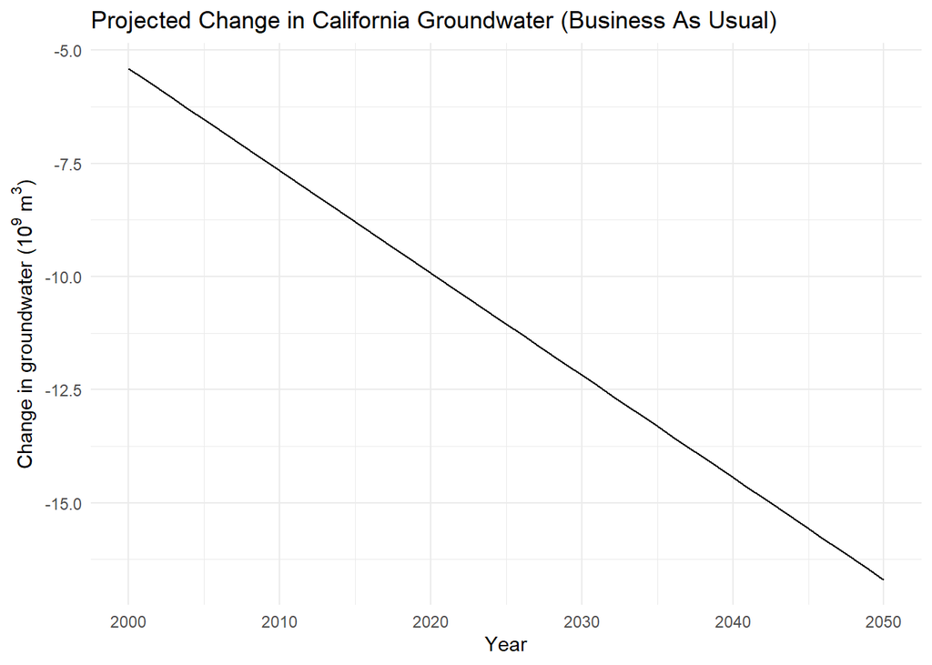

**Figure 1.** Predicted groundwater flow (10$^9$ m$^3$) from 2000 to 2050 in California given a business as usual scenario. Predicted net change in groundwater is equal to inputs minus outputs. Net change in groundwater will decrease by 2.26x10$^9$ m$^3$ every ten years. Data: Curmi et al. (2013)

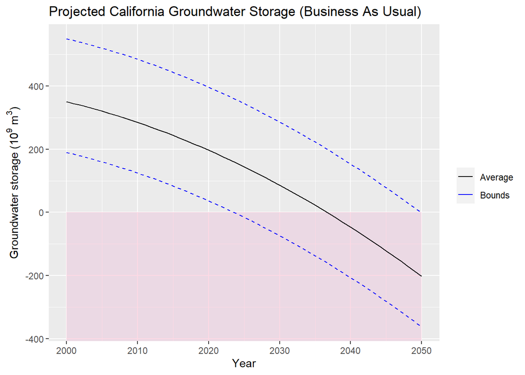

**Figure 2.** Projected total groundwater storage (10$^9$ m$^3$) in California from 2000 to 2050 under business as usual conditions. Black line represents the mean projected total groundwater storage. The initial groundwater storage level in 2000 was 350x10$^9$ m$^3$ with a standard deviation of 115x10$^9$ m$^3$. Confidence interval is 90%. Given a normal distribution, there is a 90% chance that the actual amount of groundwater in CA is between the lower limit of 190x10$^9$ m$^3$ and the upper limit of 550x10$^9$ m$^3$. Blue dashed lines show upper and lower bounds of groundwater storage. The pink box represents a level of groundwater that is at or below zero. Data: Curmi et al. (2013)

### Key Results

Figure 2:

- Projections show that if the amount of groundwater storage is higher initially, then groundwater depletion will occur later
- In a scenario where initial groundwater storage is at the lower bound (190x10$^9$ m$^3$), groundwater will be depleted by 2023
- In a scenario where initial groundwater storage is at the observed value from 2000 (350x10$^9$ m$^3$), groundwater will be depleted by 2037
- In a scenario where initial storage is at the upper bound (550x10$^9$ m$^3$), groundwater will be depleted by 2050

### Recommendations

The change in groundwater becomes more negative over time. This means an increasing amount of water is being removed from groundwater storage. Negative net change is not sustainable; change in groundwater must be positive or net zero for groundwater to be available in future years. Political action must be taken as soon as possible in order to initiate groundwater conservation before groundwater reaches critically low levels. 2023 is the earliest by which groundwater may be fully depleted (given a 90% confidence interval, and under the scenario with the least amount of starting groundwater), so action must be taken before then. Extensive policy measures to reduce water use will ensure a supply of groundwater that lasts for future generations.

### Next Steps for Analysis

Future work will integrate proposed policies into the models to see how much action is necessary to preserve groundwater resources. This will help determine what political steps must be taken, and how quickly.

Possible changes to policy include:

- Minimizing agricultural water use through increased food imports
- Raising groundwater recharge rates by reducing the ratio of concrete to natural ground in order to increase soil infiltration
- Restricting private water use, especially in drier seasons

### Citation

Curmi, Elizabeth, et al. “Visualising a Stochastic Model of Californian Water Resources Using Sankey Diagrams.” Water Resources Management, vol. 27, June 2013. ResearchGate, https://doi.org/10.1007/s11269-013-0331-2.